# Wk 3 Markdown

## Understanding the Data

The data in this document is the NYPD Shooting incident dataset taken from https://catalog.data.gov/dataset. The question trying to be answered is *what is the relationship between shooting incidents and time?*

This dataset contained shooting data from 2006 to 2020 with the occurrence time, perpatrator data, victim data, and exact location.

First, let’s try to understand the relationship between month of year and shooting incidents

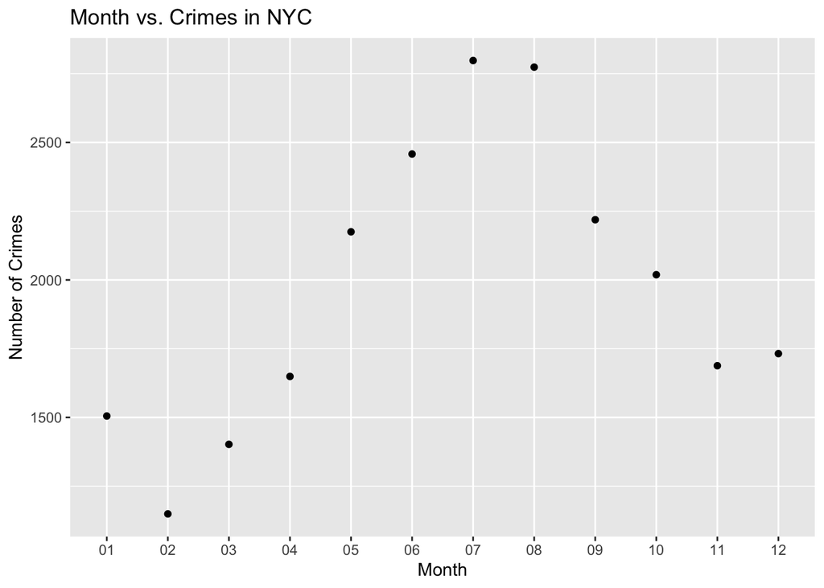

```r
nypd_data$Month <- format(as.Date(nypd_data$OCCUR_DATE), "%m")

new_dataz <- nypd_data %>% group_by(PERP_AGE_GROUP, PERP_SEX, PERP_RACE) %>% tally()

new_datas <- nypd_data %>% group_by(Month) %>% tally()

new_datas %>% ggplot(aes(x = Month, y = n))  + geom_point() + labs(title = 'Month vs. Crimes in NYC', y = 'Number of Crimes')
```

## What’s happening

What we see is a strong relationship where the months of May through August contain high amounts of shootings while the colder months contain much less shootings.

Let’s try to understand shooting incidents throughout each hour and see if the relationship is similar

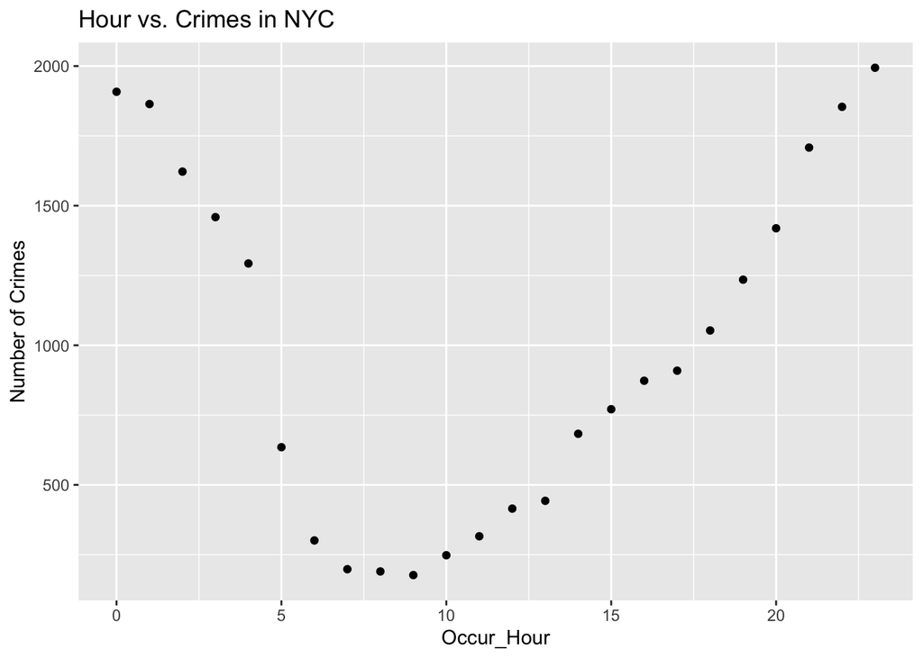

```r
nypd_data <- nypd_data %>% filter(OCCUR_TIME != '')
nypd_data$Occur_Hour <- hour(nypd_data$OCCUR_TIME)

hour_datas <- nypd_data %>% group_by(Occur_Hour) %>% tally()

hour_datas %>% ggplot(aes(x = Occur_Hour, y = n))  + geom_point() + labs(title = 'Hour vs. Crimes in NYC', y = 'Number of Crimes')
```

In this relationship, we also see a similar trend in that shooting incidents happen more during the hours 11 pm to 4 am. and strongly decrease after the fact.

To understand the relationship better, it might be best to understand a model of the hour data to best understand the relationship

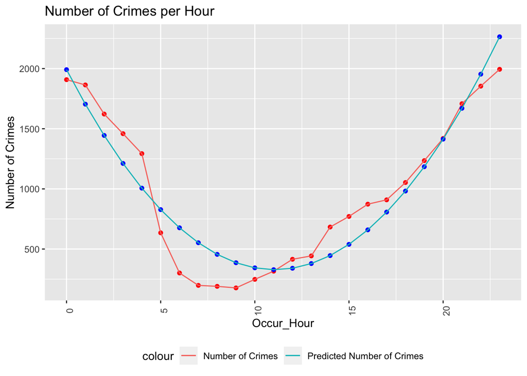

```r
nypd_data$Occur_Hour <- as.numeric(nypd_data$Occur_Hour)

mod <- lm(n ~ Occur_Hour + I(Occur_Hour^2), data = hour_datas)
predictions <- mod %>% predict(hour_datas)

hour_datas$predictions <- predictions


hour_datas %>% ggplot() +
  geom_point(aes(x = Occur_Hour, y = n), color = "red") +
  geom_line(aes(x = Occur_Hour,y = n, color = "Number of Crimes"))+
  geom_point(aes(x = Occur_Hour, y=predictions), color="blue")+
  geom_line(aes(x = Occur_Hour,y = predictions, color = "Predicted Number of Crimes"))+
  labs(title='Number of Crimes per Hour', y = 'Number of Crimes')+
  theme(legend.position = "bottom",
        axis.text.x = element_text(angle = 90))
```

In this we see that the relationship resembles a parabola where the middle of the day shows much less crimes. When looking at the residuals near the 5th to 8th hour or 5 am to 8 am, the residuals are much higher in this area than the rest of the plot. This is most likely due to the steep drop off we see in this area.

Sources of Bias may be due to the fact that many shootings are not reported immediately and the shooting times eg. actual time of occurrence may be off.